# Factors affecting Sleep

Project 2

540214264, 540754276, 540062713, 540286434, 540301162, 540496066

University of Sydney | DATA1001 | APRIL 2024

# 1 Executive Summary

# 2 Full Report

## 2.1 Initial Data Analysis (IDA)

### 2.1.1 Source

The data used in this report was collected from university students from 3/28/24 to 4/14/24 through the usage of Google Forms:  
(https://forms.gle/xxXj6JNymotvkEot5)

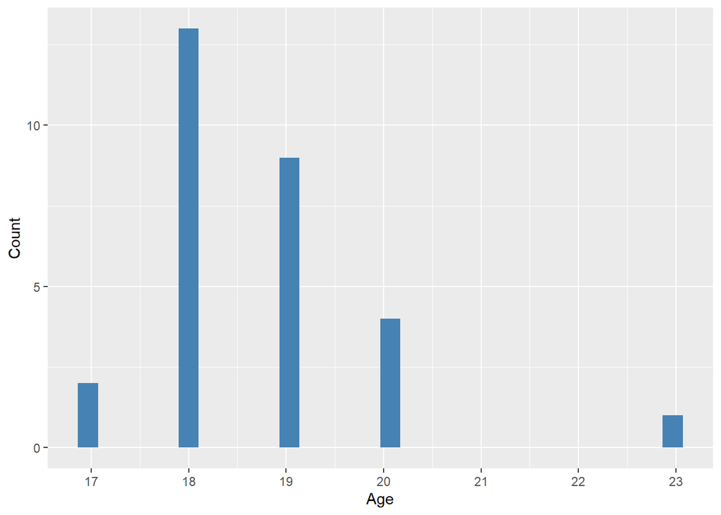

```r
# Shows barplot of ages of survey participants
library(tidyverse)
library(readr)
Responses = read_csv("./Project 2 responses - Sheet1.csv", show_col_types = FALSE)
Responses = filter(Responses, Age < 30)
ggplot(Responses) +
  geom_histogram(aes(x = Age), bins=30, fill = "steelblue") +
  labs(y = "Count") +
  scale_x_continuous(breaks = 0:23)
```

### 2.1.3 Limitations

Not everyone has a fixed sleeping schedule. It is quite likely that our survey participants had fluctuating hours of sleep throughout their weeks. This could be due to their differing school timetables, causing them to sleep and wake up at varying times.Also, the sleep quality is biased on how people judge their own sleep quality, because we are aware that everyone has their own perspective about what a good sleep quality is.

### 2.1.4 Assumptions

We assume that all survey participants will tell the truth and will take the survey seriously. Any illogical responses (i.e. age of participant being 999 years old) will not be included in our results.

### 2.1.5 Data Clearing

For data clearing, we will use a function called `filter()` to remove any illogical results that may damage the reliability of our results.

## Research theme

We will investigate the relationship between the sleeping behavior of University students and the activities they partake in during their normal day.

## 2.2 Research Question 1

How does phone usage before bed affects one’s sleep quality and hours?

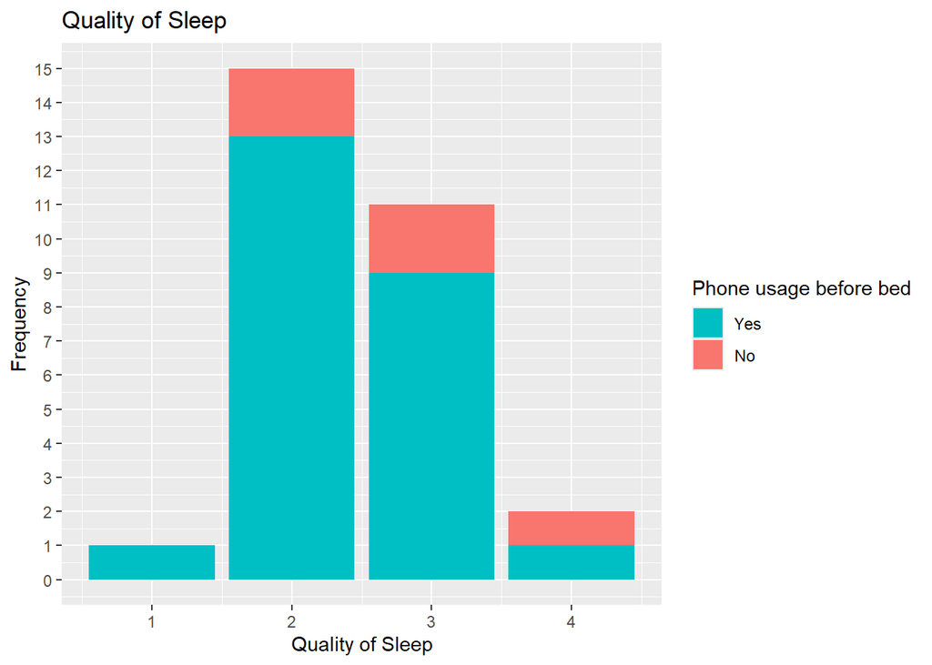

```r
library(tidyverse)
ggplot(Responses, aes(x = `Quality of sleep`)) +
  geom_bar(aes(fill= `Phone before bed`)) +
  ggtitle("Quality of Sleep ") +
  labs(x = "Quality of Sleep", y = "Frequency", fill = "Phone usage before bed") +
  scale_y_continuous(breaks = 0:15) +
  guides(fill = guide_legend(reverse = T))
```

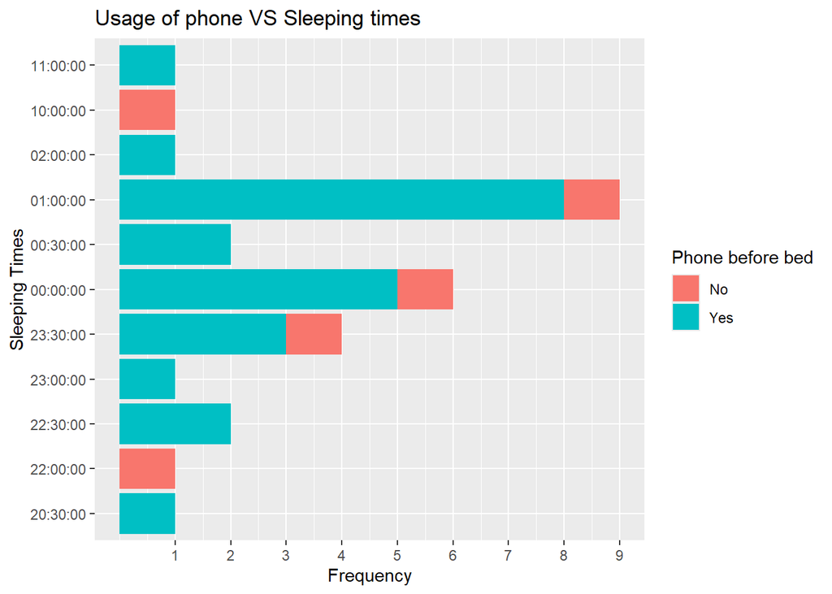

```r
library(tidyverse)
sleep_time_levels <- c("20:00:00", "20:30:00", "21:00:00", "21:30:00",
                       "22:00:00","22:30:00","23:00:00","23:30:00",
                       "00:00:00","00:30:00","01:00:00", "01:30:00",
                       "02:00:00", "10:00:00", "11:00:00")


ggplot(Responses) +
  geom_bar(aes(factor(`Sleep time`, sleep_time_levels), fill = `Phone before bed`)) +
  scale_y_continuous(breaks = 1:10) +
  ggtitle("Usage of phone VS Sleeping times") +
  ylab("Frequency") +
  xlab("Sleeping Times") +
  coord_flip()
```

## 2.3 Research Question 2

How does screen time influence duration of sleep?

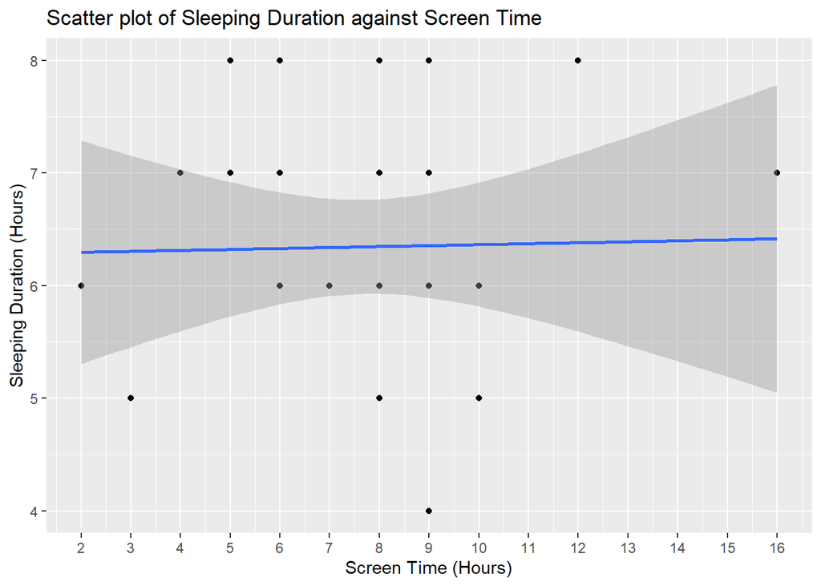

```r
Responses$`Hours of sleep` <- as.numeric(Responses$`Hours of sleep`)
Responses$`Screen time` <- as.numeric(Responses$`Screen time`)
ggplot(Responses, aes(x=`Screen time`, y=`Hours of sleep`)) +
  geom_point() +
  geom_smooth(method = 'lm', se = T) +
  scale_x_continuous(breaks = 0:16) +
  labs(x = "Screen Time (Hours)", y = "Sleeping Duration (Hours)", title = "Scatter plot of Sleeping Duration against Screen Time")
```

```r
cor(Responses$`Screen time`, Responses$`Hours of sleep`)
```

```
## [1] 0.0214867
```

Correlation Coefficient = 0.0214867  
From this linear regression graph, we can conclude that sleeping duration is not influenced by screen time since the correlation coefficient shown above is near 0 and positive. However, the area of the standard error above is incredibly significant. Hence, it could also be said that the projected values shown above are far from accurate as well.

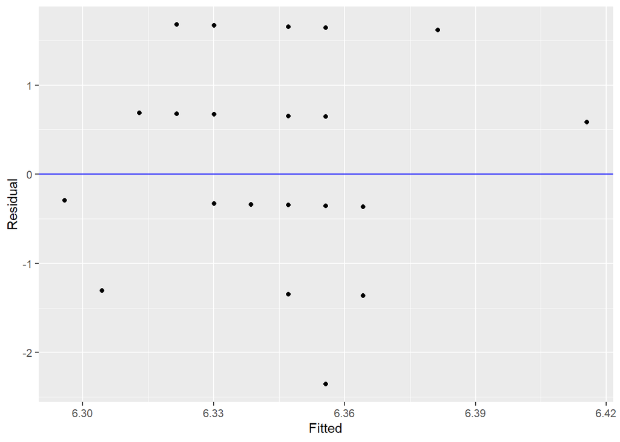

```r
l_m = lm(`Hours of sleep` ~ `Screen time`, Responses)
ggplot(l_m, aes(x=.fitted, y=.resid)) +
  geom_point() +
  ylab("Residual") +
  xlab("Fitted") +
  geom_hline(yintercept = 0, color="blue")
```

From the residual plot above, we can see that the residual plot appears to be random and supports the idea that the linear fit is appropriate for the data.

Summary:  
The data we have received is insufficient to make a hypothesis as to whether screen time has an affect on duration of sleep.

# 3 References

Style: APA

# 4 Acknowledgment

24/2/2024 Online |Braxton, William, Vincent, Alex, Mingye|- Figuring out what we want to explore and formulating research question 2/3/2024 Online |Braxton, William, Vincent, Alex, Mingye|- Started to list out variables and formulating questions 3/3/2024 Online |Braxton, William, Vincent, Alex, Mingye| - Finished off Project 1 and created a survey in Google forms 10/03/2024 Online on discord |Braxton, William, Vincent, Alex, Damara, Mingye| - Designing the plan and research topic for Project plan 14/03/2024 After Lab |Braxton, William, Vincent, Alex, Damara, Mingye| - Creating the survey questions and the google form 28/03/2024 After Lab |Braxton, William, Mingye, Damara| - Posting the survey to obtain results 15/04/2024 Online on Github |Braxton| - Creating github repo and initial scaffolding for report 17/04/2024 Online on Github |Damara| - Added research questions 18/04/2024 After Lab Online |Braxton, William, Vincent, Alex, Mingye, Damara| - Communicating report data 18/04/2024 Online on Github and Discord | Braxton, William, Vincent, Damara, Mingye| - Writing out report